# 04 – Sparse phospho data: two roadmaps

- Show All Code
- Hide All Code
- View Source

Bio253 HS2026 · reproducible vs exploratory

The phospho-enriched data are **sparse**: most sites are seen in only a few of the 27 samples. There are two honest ways to deal with that:

- **Roadmap A – reproducible:** only use sites seen in **≥ 2 of 3 replicates** of a group. Fewer sites, but you can estimate variance and do statistics.
- **Roadmap B – exploratory:** use every site seen in **≥ 1 of 3** replicates and think in *present / absent*. Many more sites, many more false leads. Good for generating hypotheses, not for confirming them.

```r
source("../R/setup.R")
SEARCH <- "STYH"   # change to "STY" to repeat everything on the STY-only search
sites <- read_sites(SEARCH)
```

## 1. How sparse?

```r
tibble(
  search = SEARCH,
  n_sites = n_distinct(sites$site_id),
  n_samples = n_distinct(sites$sample),
  percent_missing = round(100 * mean(is.na(sites$intensity)), 1)
)
```

| search | n_sites | n_samples | percent_missing |
| --- | --- | --- | --- |
| STYH | 4245 | 27 | 84.9 |

## 2. Detection depth per sample and group

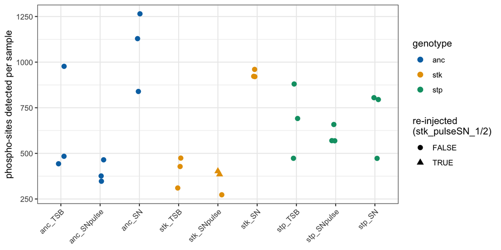

```r
depth <- sites |>
  group_by(sample, genotype, medium, group, reinjected) |>
  summarise(n_sites = sum(!is.na(intensity)), .groups = "drop")

ggplot(depth, aes(group, n_sites, colour = genotype, shape = reinjected)) +
  geom_point(size = 2.5, position = position_jitter(width = 0.1, seed = 1)) +
  scale_colour_manual(values = GENOTYPE_COLOURS) +
  scale_shape_manual(values = c(`FALSE` = 16, `TRUE` = 17)) +
  theme(axis.text.x = element_text(angle = 45, hjust = 1)) +
  labs(x = NULL, y = "phospho-sites detected per sample",
       shape = "re-injected\n(stk_pulseSN_1/2)")
```

```r
depth |>
  group_by(group) |>
  summarise(mean_sites = round(mean(n_sites)), min = min(n_sites), max = max(n_sites))
```

| group | mean_sites | min | max |
| --- | --- | --- | --- |
| anc_TSB | 635 | 443 | 977 |
| anc_SNpulse | 396 | 347 | 465 |
| anc_SN | 1078 | 839 | 1265 |
| stk_TSB | 404 | 310 | 474 |
| stk_SNpulse | 353 | 273 | 402 |
| stk_SN | 934 | 921 | 960 |
| stp_TSB | 681 | 473 | 880 |
| stp_SNpulse | 599 | 569 | 658 |
| stp_SN | 691 | 473 | 805 |

**Questions**

- How different are the groups? Is the difference biological (more phosphorylation in SN?) or technical (enrichment efficiency, injection amount, instrument day)? How could you tell the two apart?
- If a site is “missing” in the shallow groups, is it *not phosphorylated* or just *not detected*? → Missing **not** at random (MNAR). What does that do to a “TSB vs SN” comparison?

## 3. Count detections per site and group

```r
per_group <- sites |>
  group_by(site_id, locus_tag, product, residue, position, best_loc_prob, group) |>
  summarise(n_detected = sum(!is.na(intensity)), .groups = "drop")

roadmaps <- per_group |>
  group_by(site_id, residue) |>
  summarise(max_detected = max(n_detected), .groups = "drop") |>
  mutate(roadmap_A_reproducible = max_detected >= 2,
         roadmap_B_exploratory  = max_detected >= 1)

roadmaps |>
  summarise(all_sites = n(),
            roadmap_A_reproducible = sum(roadmap_A_reproducible),
            roadmap_B_exploratory = sum(roadmap_B_exploratory))
```

| all_sites | roadmap_A_reproducible | roadmap_B_exploratory |
| --- | --- | --- |
| 4245 | 1645 | 4245 |

### Sites per residue

```r
roadmaps |>
  group_by(residue) |>
  summarise(roadmap_B_exploratory = sum(roadmap_B_exploratory),
            roadmap_A_reproducible = sum(roadmap_A_reproducible)) |>
  mutate(percent_A = round(100 * roadmap_A_reproducible / sum(roadmap_A_reproducible), 1),
         percent_B = round(100 * roadmap_B_exploratory / sum(roadmap_B_exploratory), 1))
```

| residue | roadmap_B_exploratory | roadmap_A_reproducible | percent_A | percent_B |
| --- | --- | --- | --- | --- |
| H | 424 | 133 | 8.1 | 10.0 |
| S | 1743 | 803 | 48.8 | 41.1 |
| T | 1435 | 521 | 31.7 | 33.8 |
| Y | 643 | 188 | 11.4 | 15.1 |

**Question:** Prust *et al.* 2021 (*MCP*) report for *S. aureus* 55 % pS, 30 % pT, 7 % pY, 8 % pH. How does our distribution compare? Does the localisation probability filter change it? (Try `filter(best_loc_prob >= 0.75)`.)

## 4. Simple normalisation

Different samples have different total phospho signal. A minimal correction: subtract each sample’s median log2 intensity (median centring). This assumes most sites do not change – which is shaky when samples see very different numbers of sites. Keep that in mind.

```r
sites <- sites |>
  group_by(sample) |>
  mutate(log2_norm = log2_intensity - median(log2_intensity, na.rm = TRUE)) |>
  ungroup()
```

## 5. Roadmap A: statistics on reproducible sites

Comparison 1: anc TSB vs anc SN (long-term). Comparison 2: anc TSB vs anc SNpulse (15 min). We keep sites with ≥ 2 of 3 values **in both groups** and use `limma`.

```r
library(limma)

compare_reproducible <- function(sites, group_a, group_b, min_per_group = 2) {
  x <- filter(sites, group %in% c(group_a, group_b))
  keep <- x |>
    group_by(site_id, group) |>
    summarise(n = sum(!is.na(log2_norm)), .groups = "drop") |>
    group_by(site_id) |>
    filter(n_distinct(group) == 2, all(n >= min_per_group)) |>
    pull(site_id) |> unique()
  wide <- x |>
    filter(site_id %in% keep) |>
    select(site_id, sample, log2_norm) |>
    pivot_wider(names_from = sample, values_from = log2_norm)
  m <- as.matrix(wide[, -1]); rownames(m) <- wide$site_id
  grp <- factor(x$group[match(colnames(m), x$sample)], levels = c(group_a, group_b))
  design <- model.matrix(~ grp)          # coefficient 2 = group_b - group_a
  fit <- eBayes(lmFit(m, design))
  topTable(fit, coef = 2, number = Inf) |>
    as_tibble(rownames = "site_id") |>
    # flip the sign so that diff follows the course rule: A_vs_B = A - B
    transmute(site_id, contrast = paste0(group_a, "_vs_", group_b),
              diff = -logFC, p.value = P.Value, FDR = p.adjust(P.Value, "BH"))
}

res_a <- bind_rows(
  compare_reproducible(sites, "anc_TSB", "anc_SN"),
  compare_reproducible(sites, "anc_TSB", "anc_SNpulse")
)
res_a |>
  group_by(contrast) |>
  summarise(sites_tested = n(),
            FDR_below_0.1 = sum(FDR < 0.1),
            FDR_below_0.1_and_2fold = sum(FDR < 0.1 & abs(diff) > 1))
```

| contrast | sites_tested | FDR_below_0.1 | FDR_below_0.1_and_2fold |
| --- | --- | --- | --- |
| anc_TSB_vs_anc_SN | 311 | 103 | 102 |
| anc_TSB_vs_anc_SNpulse | 200 | 2 | 2 |

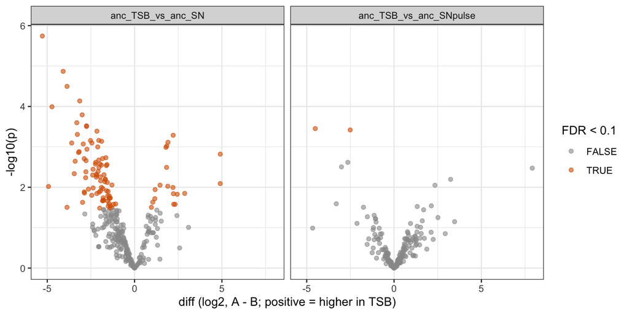

```r
ggplot(res_a, aes(diff, -log10(p.value), colour = FDR < 0.1)) +
  geom_point(alpha = 0.6) +
  facet_wrap(~contrast) +
  scale_colour_manual(values = c(`FALSE` = "grey60", `TRUE` = "#D55E00")) +
  labs(x = "diff (log2, A - B; positive = higher in TSB)", y = "-log10(p)")
```

## 6. Roadmap B: presence / absence

For each site and comparison: in how many replicates of A and of B is it seen?

```r
presence_absence <- function(per_group, group_a, group_b) {
  per_group |>
    filter(group %in% c(group_a, group_b)) |>
    select(site_id, locus_tag, product, residue, position, group, n_detected) |>
    pivot_wider(names_from = group, values_from = n_detected) |>
    rename(n_A = all_of(group_a), n_B = all_of(group_b)) |>
    filter(n_A + n_B > 0) |>
    mutate(contrast = paste0(group_a, "_vs_", group_b),
           pattern = case_when(n_A >= 1 & n_B == 0 ~ "only in A",
                               n_B >= 1 & n_A == 0 ~ "only in B",
                               TRUE ~ "in both"))
}

res_b <- bind_rows(presence_absence(per_group, "anc_TSB", "anc_SN"),
                   presence_absence(per_group, "anc_TSB", "anc_SNpulse"))

res_b |> count(contrast, pattern) |>
  pivot_wider(names_from = pattern, values_from = n)
```

| contrast | in both | only in A | only in B |
| --- | --- | --- | --- |
| anc_TSB_vs_anc_SN | 751 | 476 | 1080 |
| anc_TSB_vs_anc_SNpulse | 413 | 814 | 366 |

How convincing is “only in A”? A 3-vs-0 pattern is much stronger than 1-vs-0:

```r
res_b |>
  filter(pattern != "in both") |>
  mutate(strength = if_else(pattern == "only in A", paste0(n_A, " vs 0"), paste0("0 vs ", n_B))) |>
  count(contrast, pattern, strength) |>
  pivot_wider(names_from = strength, values_from = n, values_fill = 0)
```

| contrast | pattern | 1 vs 0 | 2 vs 0 | 3 vs 0 | 0 vs 1 | 0 vs 2 | 0 vs 3 |
| --- | --- | --- | --- | --- | --- | --- | --- |
| anc_TSB_vs_anc_SN | only in A | 397 | 70 | 9 | 0 | 0 | 0 |
| anc_TSB_vs_anc_SN | only in B | 0 | 0 | 0 | 679 | 263 | 138 |
| anc_TSB_vs_anc_SNpulse | only in A | 625 | 147 | 42 | 0 | 0 | 0 |
| anc_TSB_vs_anc_SNpulse | only in B | 0 | 0 | 0 | 335 | 24 | 7 |

The strongest candidates (3 vs 0) for the long-term comparison:

```r
res_b |>
  filter(contrast == "anc_TSB_vs_anc_SN", (n_A == 3 & n_B == 0) | (n_A == 0 & n_B == 3)) |>
  mutate(site = paste0(residue, position)) |>
  select(pattern, locus_tag, product, site, n_A, n_B) |>
  arrange(pattern, locus_tag)
```

| pattern | locus_tag | product | site | n_A | n_B |
| --- | --- | --- | --- | --- | --- |
| only in A | B7H15_01765 | lipase | S610 | 3 | 0 |
| only in A | B7H15_05835 | phosphopantetheine adenylyltransferase | T4 | 3 | 0 |
| only in A | B7H15_06085 | ornithine carbamoyltransferase | H272 | 3 | 0 |
| only in A | B7H15_06820 | glutamine synthetase | Y375 | 3 | 0 |
| only in A | B7H15_08890 | CsbD family protein | T52 | 3 | 0 |
| only in A | B7H15_09545 | dipeptidase PepV | Y337 | 3 | 0 |
| only in A | B7H15_11535 | potassium-transporting ATPase subunit B | S159 | 3 | 0 |
| only in A | B7H15_12150 | Asp23/Gls24 family envelope stress response protein | S89 | 3 | 0 |
| only in A | B7H15_13270 | respiratory nitrate reductase subunit gamma | T200 | 3 | 0 |
| only in B | B7H15_00030 | DNA gyrase subunit A | S63 | 0 | 3 |
| only in B | B7H15_00710 | diacetyl reductase ((S)-acetoin forming) | Y243 | 0 | 3 |
| only in B | B7H15_01055 | PTS glucose EIICBA component | S417 | 0 | 3 |
| only in B | B7H15_01055 | PTS glucose EIICBA component | S459 | 0 | 3 |
| only in B | B7H15_01055 | PTS glucose EIICBA component | S547 | 0 | 3 |
| only in B | B7H15_01055 | PTS glucose EIICBA component | S672 | 0 | 3 |
| only in B | B7H15_01055 | PTS glucose EIICBA component | T425 | 0 | 3 |
| only in B | B7H15_01205 | formate acetyltransferase | S42 | 0 | 3 |
| only in B | B7H15_01205 | formate acetyltransferase | S462 | 0 | 3 |
| only in B | B7H15_01205 | formate acetyltransferase | S525 | 0 | 3 |
| only in B | B7H15_01205 | formate acetyltransferase | S603 | 0 | 3 |
| only in B | B7H15_01205 | formate acetyltransferase | S642 | 0 | 3 |
| only in B | B7H15_01205 | formate acetyltransferase | S723 | 0 | 3 |
| only in B | B7H15_01205 | formate acetyltransferase | T10 | 0 | 3 |
| only in B | B7H15_01205 | formate acetyltransferase | T4 | 0 | 3 |
| only in B | B7H15_01205 | formate acetyltransferase | T602 | 0 | 3 |
| only in B | B7H15_01205 | formate acetyltransferase | T81 | 0 | 3 |
| only in B | B7H15_01205 | formate acetyltransferase | Y223 | 0 | 3 |
| only in B | B7H15_01205 | formate acetyltransferase | Y37 | 0 | 3 |
| only in B | B7H15_01205 | formate acetyltransferase | Y607 | 0 | 3 |
| only in B | B7H15_01395 | iron-sulfur cluster repair protein ScdA | S67 | 0 | 3 |

[output cut: 117 more lines]

**WarningPresence/absence and the depth problem**

anc_SN samples detect roughly **twice as many** sites as the other ancestor groups. So “only in SN” is *expected* for many sites even if nothing biological happens. How would you correct for that? (Ideas: compare to the number of “only in” sites you get for random sample groupings; require the site’s protein to be detected in both groups in the total proteome; look at intensity – sites that are “absent” in TSB but very intense in SN are more convincing than faint ones.)

## 7. Compare with the prolfquapp DEA

The lecturer’s DEA (`read_dea("phospho_STYH")`) uses all sites and **imputes** missing group means. How many of its “hits” rest on imputed values?

```r
dea_p <- read_dea(paste0("phospho_", SEARCH))
dea_p |>
  filter(contrast %in% c("TSB_vs_SN_at_anc", "TSB_vs_SNpulse_at_anc")) |>
  group_by(contrast) |>
  summarise(sites = n(),
            hits = sum(FDR < 0.1 & abs(diff) > 1),
            hits_observed = sum(FDR < 0.1 & abs(diff) > 1 & estimate_type == "observed"),
            hits_imputed = sum(FDR < 0.1 & abs(diff) > 1 & estimate_type == "lod_imputed"))
```

| contrast | sites | hits | hits_observed | hits_imputed |
| --- | --- | --- | --- | --- |
| TSB_vs_SN_at_anc | 4235 | 118 | 26 | 92 |
| TSB_vs_SNpulse_at_anc | 4235 | 53 | 4 | 49 |

**Questions**

- Do roadmap A and the prolfquapp DEA agree for the sites that both test? (Hint: join `res_a` with `dea_p` by `site_id`; mind the contrast names.)
- A phospho-site intensity changes if the *phosphorylation* changes **or** if the *protein amount* changes. TSB vs SN changes ~450 proteins (notebook 01). How would you correct site intensities for protein abundance?
- Which roadmap would you use to **confirm** a hypothesis, which to **find** one?